# Practical Machine Learning Project

Braydon

1/12/2020

# Overview

Using devices such as Jawbone Up, Nike FuelBand, and Fitbit it is now possible to collect a large amount of data about personal activity relatively inexpensively. These type of devices are part of the quantified self movement - a group of enthusiasts who take measurements about themselves regularly to improve their health, to find patterns in their behavior, or because they are tech geeks. One thing that people regularly do is quantify how much of a particular activity they do, but they rarely quantify how well they do it. In this project, your goal will be to use data from accelerometers on the belt, forearm, arm, and dumbell of 6 participants. They were asked to perform barbell lifts correctly and incorrectly in 5 different ways. More information is available from the website here: http://groupware.les.inf.puc-rio.br/har (see the section on the Weight Lifting Exercise Dataset).

# Prep Work

```r
rm(list=ls())
library(dplyr)
library(knitr)
library(caret)
```

```r
library(corrplot)
library(randomForest)
library(rpart)
library(rpart.plot)
library(rattle)
library(gbm)
```

# Load Data & Create Training/Test Set

```r
# Load the data
UrlTrain <- "http://d396qusza40orc.cloudfront.net/predmachlearn/pml-training.csv"
UrlTest  <- "http://d396qusza40orc.cloudfront.net/predmachlearn/pml-testing.csv"

training <- read.csv(url(UrlTrain))
testing <- read.csv(url(UrlTest))

# Create data partition

inTrain <- createDataPartition(training$classe,p=0.7,list=FALSE)
train <- training[inTrain,]
test <- training[-inTrain,]
```

# Remove vaiables that are mostly NA and near zero values

```r
# Near Zero Variance Columns

near_zero <- nearZeroVar(train)
train <- train[,-near_zero]
test <- test[,-near_zero]

# NA Columns with 95% NA values

AllNA <- sapply(train, function(x) mean(is.na(x))) > 0.95
train <- train[,AllNA==FALSE]
test <- test[,AllNA==FALSE]

# Remove PII Columns

train <- train[,-(1:5)]
test <- test[,-(1:5)]
```

# Variable Correlation

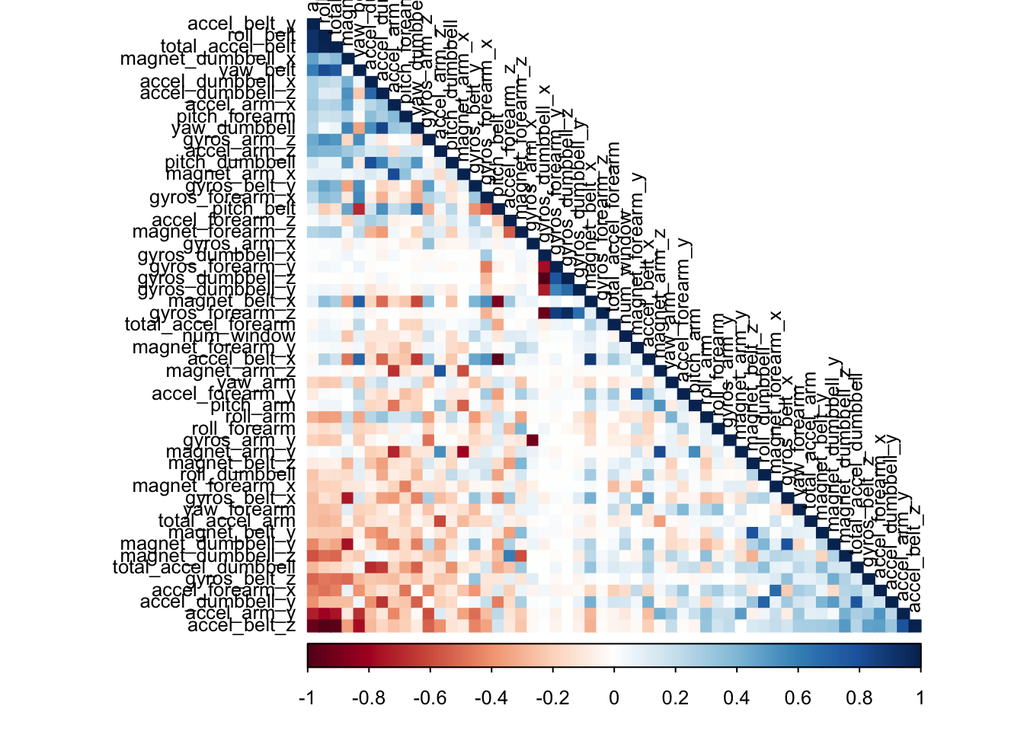

```r
# Correlation prior to moving on to modelling

corMatrix <- cor(train[,-54])
corrplot(corMatrix,order = "FPC",method = "color", type = "lower",tl.cex = 0.8, tl.col = rgb(0,0,0))
```

# Prediction Models

```r
# Method: Random Forest - Fitting the Model

set.seed(1234)
RFcontrol <- trainControl(method = "cv", number=5,verboseIter = FALSE)
FitRFmodel <- train(classe~., data = train, method = "rf", trControl = RFcontrol)
FitRFmodel$finalModel
```

```
##
## Call:
##  randomForest(x = x, y = y, mtry = param$mtry)
##                Type of random forest: classification
##                      Number of trees: 500
## No. of variables tried at each split: 27
##
##         OOB estimate of  error rate: 0.25%
## Confusion matrix:
##      A    B    C    D    E  class.error
## A 3905    0    0    0    1 0.0002560164
## B    7 2649    2    0    0 0.0033860045
## C    0    5 2391    0    0 0.0020868114
## D    0    0   12 2239    1 0.0057726465
## E    0    0    0    6 2519 0.0023762376
```

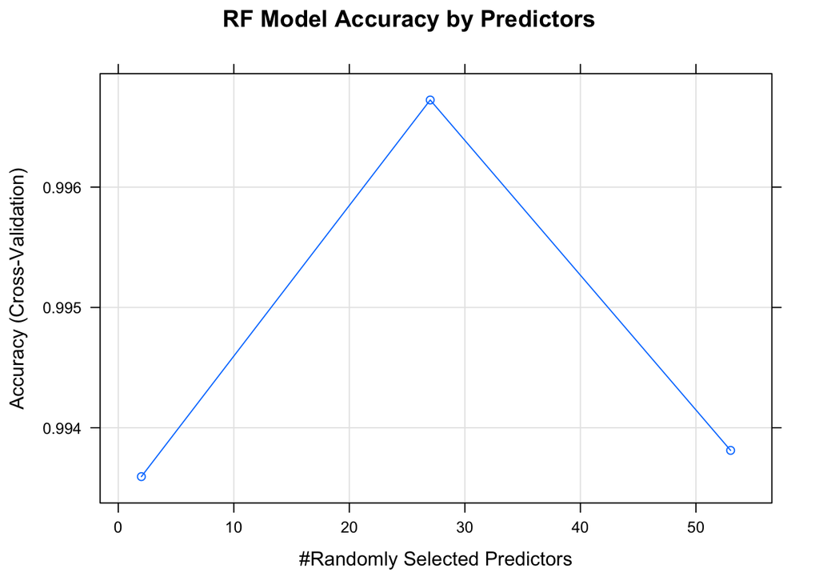

```r
plot(FitRFmodel,main="RF Model Accuracy by Predictors")
```

```r
# Method: Random Forest - Testing the Model
RF_Predict <- predict(FitRFmodel,newdata = test)
RF_cm <- confusionMatrix(test$classe,RF_Predict)
RF_cm
```

```
## Confusion Matrix and Statistics
##
##           Reference
## Prediction    A    B    C    D    E
##          A 1673    1    0    0    0
##          B    5 1134    0    0    0
##          C    0    5 1021    0    0
##          D    0    0    2  962    0
##          E    0    0    0    0 1082
##
## Overall Statistics
##
##                Accuracy : 0.9978
##                  95% CI : (0.9962, 0.9988)
##     No Information Rate : 0.2851
##     P-Value [Acc > NIR] : < 2.2e-16
##
##                   Kappa : 0.9972
##
##  Mcnemar's Test P-Value : NA
##
## Statistics by Class:
##
##                      Class: A Class: B Class: C Class: D Class: E
## Sensitivity            0.9970   0.9947   0.9980   1.0000   1.0000
## Specificity            0.9998   0.9989   0.9990   0.9996   1.0000
## Pos Pred Value         0.9994   0.9956   0.9951   0.9979   1.0000
## Neg Pred Value         0.9988   0.9987   0.9996   1.0000   1.0000
## Prevalence             0.2851   0.1937   0.1738   0.1635   0.1839
## Detection Rate         0.2843   0.1927   0.1735   0.1635   0.1839
## Detection Prevalence   0.2845   0.1935   0.1743   0.1638   0.1839
## Balanced Accuracy      0.9984   0.9968   0.9985   0.9998   1.0000
```

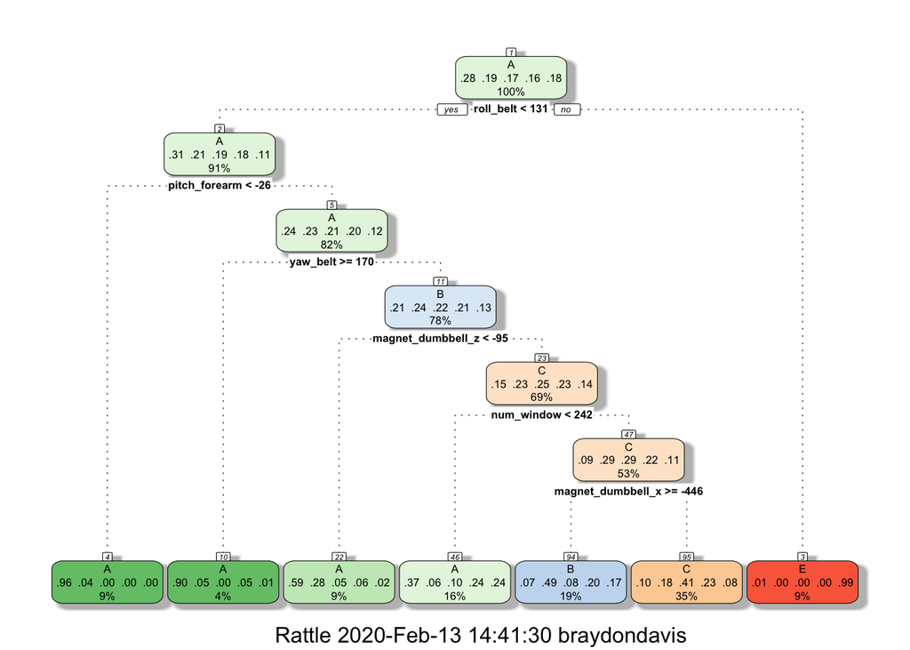

```r
# Method: Decision Tree - Fitting the Model

DTcontrol <- trainControl(method = "cv", number=5,verboseIter = FALSE)
DT_Model <- train(classe~., data=train, method="rpart", trControl=DTcontrol)
fancyRpartPlot(DT_Model$finalModel)
```

```r
# Method: Decision Tree - Testing the Model
DT_Predict <- predict(DT_Model,newdata = test)
DT_cm <- confusionMatrix(test$classe,DT_Predict)
DT_cm
```

```
## Confusion Matrix and Statistics
##
##           Reference
## Prediction    A    B    C    D    E
##          A 1390   77  204    0    3
##          B  250  531  358    0    0
##          C  108   76  842    0    0
##          D  280  225  459    0    0
##          E  231  216  162    0  473
##
## Overall Statistics
##
##                Accuracy : 0.5499
##                  95% CI : (0.5371, 0.5626)
##     No Information Rate : 0.3839
##     P-Value [Acc > NIR] : < 2.2e-16
##
##                   Kappa : 0.4221
##
##  Mcnemar's Test P-Value : NA
##
## Statistics by Class:
##
##                      Class: A Class: B Class: C Class: D Class: E
## Sensitivity            0.6153  0.47200   0.4158       NA  0.99370
## Specificity            0.9217  0.87227   0.9523   0.8362  0.88741
## Pos Pred Value         0.8303  0.46620   0.8207       NA  0.43715
## Neg Pred Value         0.7936  0.87484   0.7565       NA  0.99938
## Prevalence             0.3839  0.19116   0.3441   0.0000  0.08088
## Detection Rate         0.2362  0.09023   0.1431   0.0000  0.08037
## Detection Prevalence   0.2845  0.19354   0.1743   0.1638  0.18386
## Balanced Accuracy      0.7685  0.67213   0.6841       NA  0.94055
```

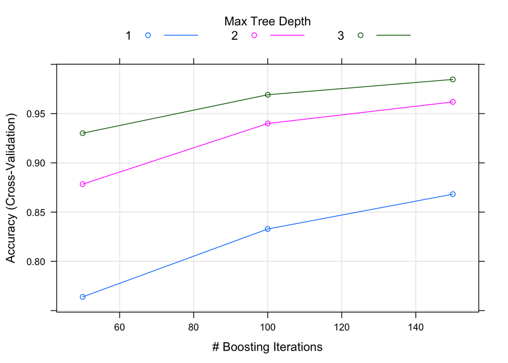

```r
# Method: Generalized Boosted Model - Fitting the Model

GBMcontrol <- trainControl(method = "cv", number=3,verboseIter = FALSE)
GBM_Model <- train(classe~., data=train, method="gbm", trControl=GBMcontrol, verbose=FALSE)
plot(GBM_Model)
```

```r
# Method: Gradient Boosted Model - Testing the Model
GBM_Predict <- predict(GBM_Model,newdata=test)
GBM_cm <- confusionMatrix(test$classe,GBM_Predict)
GBM_cm
```

```
## Confusion Matrix and Statistics
##
##           Reference
## Prediction    A    B    C    D    E
##          A 1673    1    0    0    0
##          B    6 1128    5    0    0
##          C    0    4 1009   13    0
##          D    1    2    9  950    2
##          E    0    2    0    6 1074
##
## Overall Statistics
##
##                Accuracy : 0.9913
##                  95% CI : (0.9886, 0.9935)
##     No Information Rate : 0.2855
##     P-Value [Acc > NIR] : < 2.2e-16
##
##                   Kappa : 0.989
##
##  Mcnemar's Test P-Value : NA
##
## Statistics by Class:
##
##                      Class: A Class: B Class: C Class: D Class: E
## Sensitivity            0.9958   0.9921   0.9863   0.9804   0.9981
## Specificity            0.9998   0.9977   0.9965   0.9972   0.9983
## Pos Pred Value         0.9994   0.9903   0.9834   0.9855   0.9926
## Neg Pred Value         0.9983   0.9981   0.9971   0.9961   0.9996
## Prevalence             0.2855   0.1932   0.1738   0.1647   0.1828
## Detection Rate         0.2843   0.1917   0.1715   0.1614   0.1825
## Detection Prevalence   0.2845   0.1935   0.1743   0.1638   0.1839
## Balanced Accuracy      0.9978   0.9949   0.9914   0.9888   0.9982
```

# Conclusion

## By comparing the accuracy rate of all three models, it can be determined that the best fitting model is Random Forest.